# Primeros pasos con R y RStudio

Guía de instalación y configuración inicial

AUTOR

CURSO

Sebastián Valdivia Ramírez

GEO3211-1 · Introducción a la Programación en Geografía

Fecha de publicación

marzo 2026

## 1 Descarga e Instalación de R

Para instalar la última versión disponible de R ingrese al sitio web de CRAN (*The Comprehensive R Archive Network*) https://cran.r-project.org/bin/windows/base/. Una vez allí haga clic en `Download R-4.5.3 for Windows` para iniciar la descarga Figura 1.

[figure not shown]

Figura 1: Descarga de R desde CRAN

**Nota**

Para descargar la versión de R compatible con MacOS ingrese a este link https://cran.r-project.org/bin/macosx/.

Luego de finalizada la descarga abra el archivo `R-4.5.3-win.exe` para comenzar con el proceso de instalación. Siga las instrucciones que aparecen en las imágenes que se muestran a continuación.

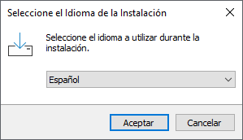

Figura 2: Idioma de instalación

2. Presione **Siguiente** para aceptar las condiciones de uso. (Figura 3).

[figure not shown]

Figura 3: Condiciones de uso de R

3. Haga clic en **Siguiente** para **aceptar la ruta de instalación** que viene por defecto. (Figura 4).

[figure not shown]

Figura 4: Directorio de instalación de R

4. En la ventana de la Figura 5 **desactive la casilla Message translations** y luego **presione** **Siguiente**.

[figure not shown]

Figura 5: Componentes de instalación

**Advertencia**

Debido a que la mayoría de la documentación y literatura de R está en inglés se recomienda fuertemente que desactiven la casilla *Message translations*.

5. En la ventana de la Figura 6 **escoja la opción** **No** y luego **presione** **Siguiente**.

[figure not shown]

Figura 6: Componentes de instalación

6. En la ventana de la (Figura 7) **presione** **Siguiente** para aceptar que se cree una carpeta en el Menú Inicio.

[figure not shown]

Figura 7: Componentes de instalación

7. **Modifique las casillas** de acuerdo a la Figura 8 y luego **presione** **Siguiente** para comenzar con la instalación.

[figure not shown]

Figura 8: Componentes de instalación

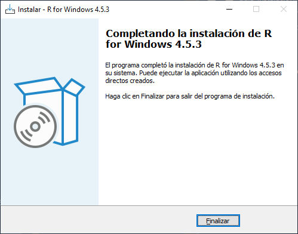

Figura 9: Componentes de instalación

Para comprobar que la instalación se haya realizado correctamente haga clic en el Menú Inicio > carpeta R, y luego abra el archivo que pertenezca a la versión recién instalada. Si la ventana que aparece es similar a la (Figura 10) significa que R se instaló en su computador.

[figure not shown]

Figura 10: Consola nativa de R

## 2 Descarga e Instalación de RStudio

Para descargar la última versión de RStudio ingrese al sitio web https://posit.co/download/rstudio-desktop/ y haga clic en el botón `DOWNLOAD RSTUDIO DESKTOP FOR WINDOWS` (Figura 11) . La versión compatible con sistemas operativos como MacOS o Linux se encuentra disponible para descarga en la sección `All Installers and Tarballs`.

[figure not shown]

Figura 11: Componentes de instalación

Al abrir el archivo descargado se desplegará la ventana de inicio de instalación de RStudio (Figura 12). Siga las instrucciones que aparecen en las imágenes que se muestran a continuación.

1. **Presione** el botón **Siguiente** (Figura 12).

[figure not shown]

Figura 12: Ventana de bienvenida

2. **Acepte la ruta de instalación** que aparece por defecto (Figura 13). **Para finalizar** la instalación **haga clic** en **Instalar**.

[figure not shown]

Figura 13: Componentes de instalación

3. Una vez finalizada la instalación aparecerá una ventana similar a la Figura 14. Haga **clic** en **Terminar** para completar el proceso de instalación.

[figure not shown]

   Figura 14: Ventana final de instalación

Para comprobar que RStudio se instaló correctamente haga clic en el Menú Inicio y luego en la aplicación RStudio. Si se despliega una ventana similar a la Figura 15 significa que la instalación se realizó de forma correcta.

[figure not shown]

Figura 15: Ventana principal de RStudio

## 3 Configuración inicial de RStudio

A continuación se configurarán algunas opciones generales que serán de ayuda para interactuar de manera más fácil con RStudio.

En la barra superior de la ventana de RStudio (Figura 15) haga clic en `Tools` > `Global Options` > sección `General` > y luego en la pestaña `Basic` (Figura 16).

[figure not shown]

Figura 16: Global Options > General > Basic

Observe esta pestaña y ajuste las opciones de acuerdo a lo siguiente:

- **Desactivar** la **casilla** “Restore most recently opened project at startup”.
- **Desactivar** la **casilla** “Restore previously open source document at startup”.
- **Desactivar** la **casilla** “Restore .RData into workspace at startup”.
- **Escoger** la **opción** “Never” en la casilla “Save workspace to .RData on exit”.
- **Desactivar** la **casilla** “Always save history (even when not saving.RData)”.
- **Desactivar** la **casilla** “Automatically notify me of updates of RStudio”.

Diríjase a la sección `Code` y seleccione la pestaña `Editing` (Figura 17). Una vez ahí **active la casilla** “Use native pipe operator, |> (requires R 4.1+)” .

[figure not shown]

Figura 17: Global options > Code> Editing

En la misma a la sección `Code` seleccione la pestaña `Display` y marque las siguientes opciones de acuerdo a la (Figura 18).

[figure not shown]

Figura 18: Global options > Code> Display

Finalmente diríjase a la pestaña `Saving`, haga clic en el botón `Change…` y seleccione la opción `UTF-8` (Figura 19) .

[figure not shown]

Figura 19: Global Options > Code > Saving

Para guardar todos estos cambios haga clic en el botón `OK` en la ventana de `Global` `Options` .

**Nota**

La configuración inicial de RStudio se realiza una vez por computador, por lo tanto, no es necesario hacerla la próxima vez que utilice RStudio a menos que utilice otro computador.